# Covoiturage - L’offre et la demande

cb

04/12/2020

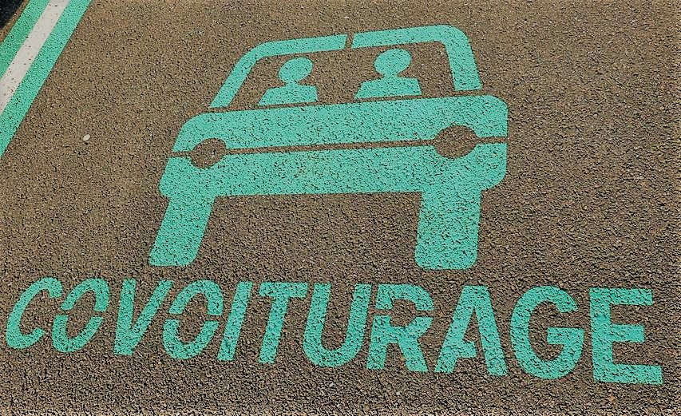

## Outils

```r
knitr::opts_chunk$set(include=TRUE, echo=TRUE, message=FALSE, warning=FALSE)
library(tidyverse)
library(reshape2) #manipuler les fichiers
library(gridExtra)
library(lme4)
library(jtools)
library(interactions)
```

## Données et recodage

C’est un vieux jeu de données scrappées sur un site de covoiturage. Environ 13000 offres proposées sur différents types de trajets et de destination à un moment donné (au cours de 2016). Je voulais à l’époque tester l’effet des signaux de qualités sur les comportements dans l’environnement collaboratif. S’agit-il d’un marché ou d’un réseau d’entraide ?

Si elles ne sont plus d’actualité, elle permettent cependant une étude intéressante des facteurs qui encourage la demande mais aussi d’analyser des facteurs d’offre et notamment les déterminants du prix. A cette période les conducteurs avaient le loisir de fixer leur prix même si une recommandation était donnée par la plateforme. On sera en particulier attentif au rôle du système de réputation dont la plateforme a fait le cœur de son modèle (cf DREAMS de bBablacar).

```r
df <- read_delim("covoit.csv", ";", escape_double = FALSE, trim_ws = TRUE)
df<- df%>% rename(TauxOccup=`Places Restantes`,
                  Depart=`Ville Depart Capture`,
                  Arrivee=`Ville Arrivee Capture`,
                  Flex=`Flexibilite Horaire`

                  )
df<-df %>% filter( Distance<1000)

#on recode les places restantes par une approximation du taux de réservation
df$Occup<- NA
df$Occup[df$TauxOccup==0]<-1
df$Occup[df$TauxOccup==1]<-.75
df$Occup[df$TauxOccup==2]<-.50
df$Occup[df$TauxOccup==3]<-.25
df$Occup[df$TauxOccup==4]<-0
df$Occup[df$TauxOccup>=4]<-0

#l'expérience peut se capter par le nombre de voyages
df$Nombre[is.na(df$Nombre)]<-0
```

Voici la liste des requêtes et le nombre d’offres obtenues pour chacune d’elle. On observe la domination des trajet inter-régionaux avec Nantes-Rennes , Toulouse-Montpellier et Bordeaux-Toulouse. Et Paris bien sur…

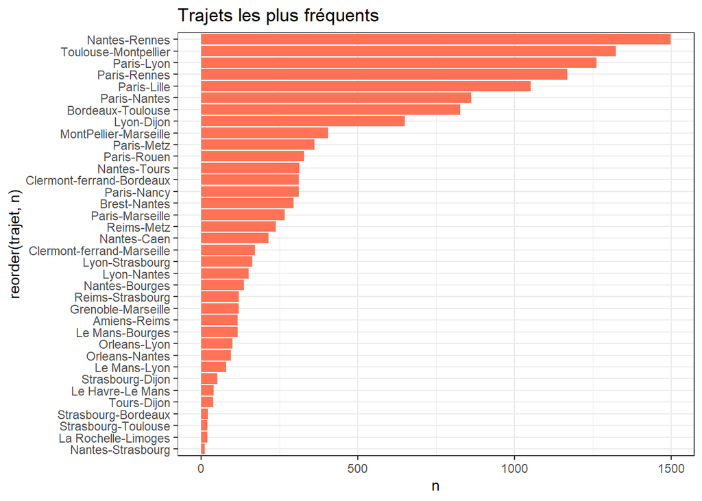

```r
trajet<-table(df$Depart, df$Arrivee)

df$trajet<-paste0(df$Depart,"-",df$Arrivee)
foo<-df %>% mutate(n=1)%>%group_by(trajet)%>%summarise(n=sum(n))%>%filter(n>0)

ggplot(foo,aes(x=reorder(trajet,n), y=n))+geom_bar(stat="identity", fill="coral1")+coord_flip()+theme_bw()+labs(title="Trajets les plus fréquents")
```

## Un tour d’horizon des déterminants ptentiel du prix et des taux d’occupation.

### La distance

Les trajets ont été échantillonnés pour représenter différents niveaux d’échelle de distance, les cours trajets, les trajets de 100 à 200 km, ceux à 300-400 et une minorité de distance plus longue, ce qui explique la concentration à certains niveaux. LA distribution ne représente pas la distribution de la demande des trajets, ni même l’offre. L’échantillon est en fait un pool d’offres pour un trajet donné.

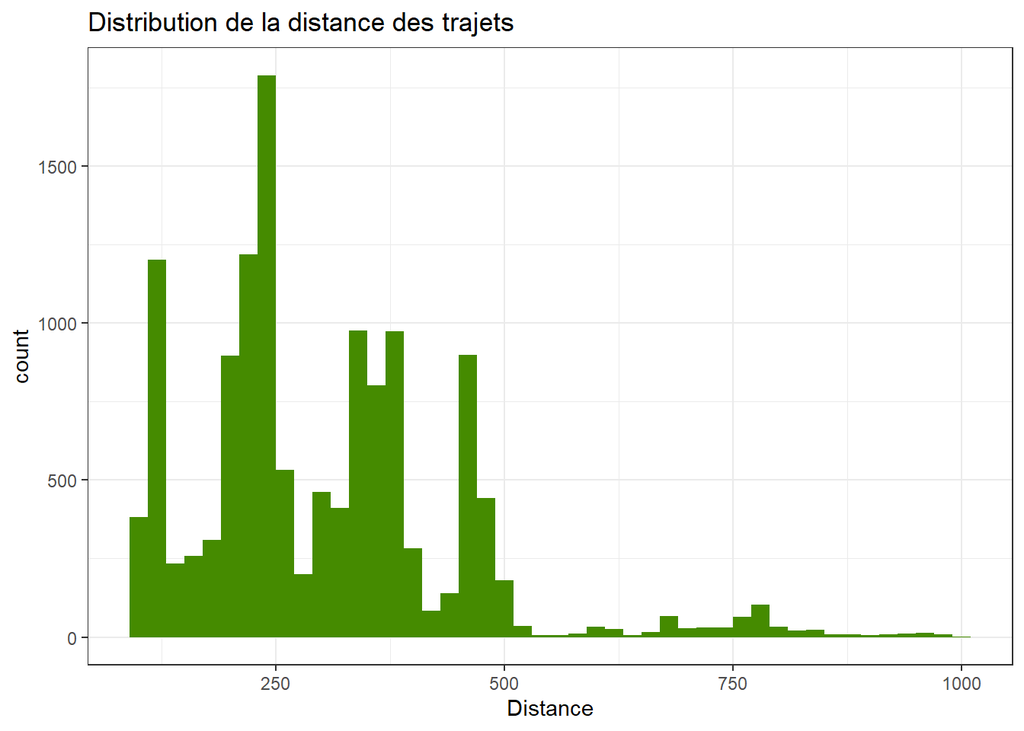

```r
ggplot(df, aes(x=Distance))+geom_histogram(fill="Chartreuse4",binwidth = 20)+theme_bw() +labs(title = "Distribution de la distance des trajets")
```

### La voiture

à traiter et d’abord recoder. Rôle de la marque et du standing du véhicule

```r
# ggplot(df, aes(x=Marque))+geom_bar(fill="Chartreuse4")+theme_bw() +coord_flip()
```

### L’âge du capitaine

On distingue deux populations en terme d’âge, une en dessous de la trentaine, l’autre de 40 à 50 ans. On Jette un coup d’oeil ensuite sur la relation entre l’âge et la note qui culmine à 30 ans et baisse avec les décades (F=59.3). Est-ce l’effet d’une inadéquation des âges? La demande est-elle plus jeune que l’offre? Celà crée-t-il un biais systématique d’évaluation?

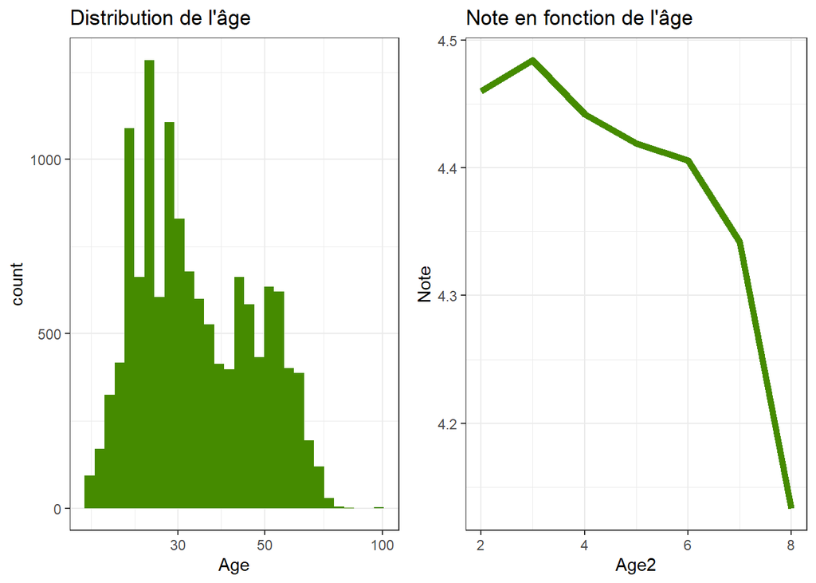

```r
g2<-ggplot(df, aes(x=Age))+
  geom_histogram(fill="Chartreuse4")+theme_bw() +
  scale_x_log10() +labs(title="Distribution de l'âge")


df$Age2<-(round(df$Age/10,0))

foo<-df %>% group_by(Age2)%>%
  summarise(Note=mean(Note, na.rm=TRUE)) %>%
  filter(Age2<9)


g3<-ggplot(foo, aes(x=Age2, y=Note, group=1))+
  geom_line(stat="identity",color="Chartreuse4",size =2)+
  theme_bw()+
  labs(title="Note en fonction de l'âge")

grid.arrange(g2,g3,ncol=2)
```

```r
fit<-lm(Note~Age2, df)
anova(fit)
```

```
## Analysis of Variance Table
##
## Response: Note
##              Df  Sum Sq Mean Sq F value    Pr(>F)
## Age2          1    6.47  6.4686  59.325 1.444e-14 ***
## Residuals 11732 1279.21  0.1090
## ---
## Signif. codes:  0 '***' 0.001 '**' 0.01 '*' 0.05 '.' 0.1 ' ' 1
```

### Le trajet

Le conducteur peut être flexible dans l’horaire de départ ou pas. Un petit recodage est cependant néçessaire.

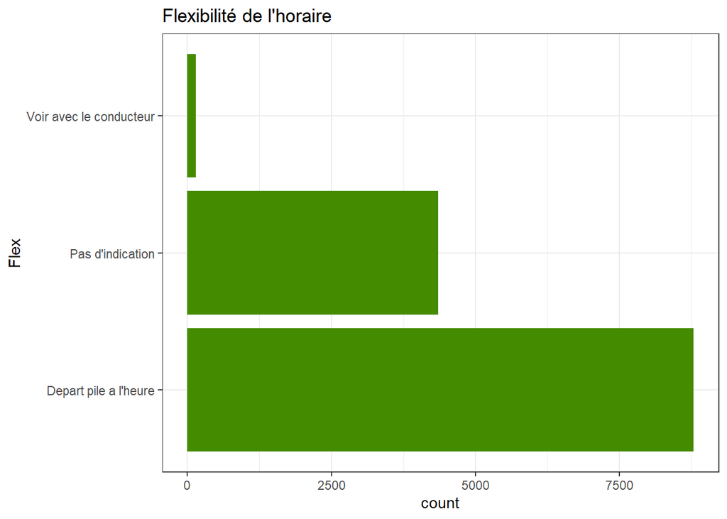

```r
df$Flex[df$Flex!="Depart pile a l'heure" & df$Flex!="Pas d'indication"]<-"Voir avec le conducteur"
df$Flex[is.na(df$Flex)]<-"Pas d'indication"

ggplot(df, aes(x=Flex))+geom_bar(fill="Chartreuse4")+theme_bw() +coord_flip()+labs(title="Flexibilité de l'horaire")
```

Le trajet peut être strict ou comporter des détours. Là aussi besoin d’un peu de recodage.

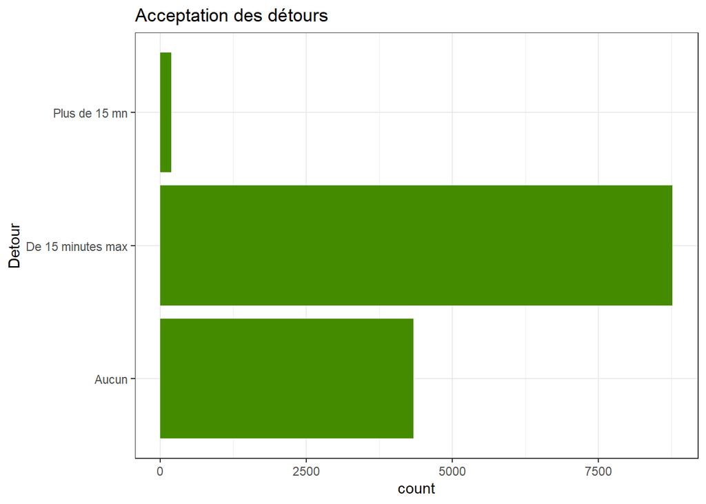

```r
df$Detour[df$Detour=="De 30 minutes max"]<-"Plus de 15 mn"
df$Detour[df$Detour=="Autant que possible"]<-"Plus de 15 mn"
ggplot(df, aes(x=Detour))+geom_bar(fill="Chartreuse4")+theme_bw()  +coord_flip()+labs(title="Acceptation des détours")
```

### le conducteur : les notes et l’expérience et statut

Le conducteur se manifeste au travers de 3 critères : son statut attribué par covoitureur, la note moyenne reçue des passagers et son expérience traduite par le nombre de voyage qu’il a fait.

Examinons le statut et notamment en comparant l’expérience et l’évaluation.

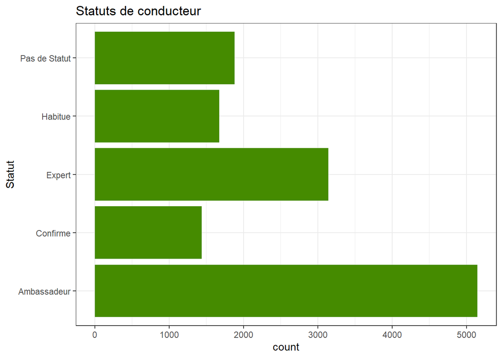

```r
df$Statut<-as.factor(df$Statut)
ggplot(df, aes(x=Statut))+
  geom_bar(fill="Chartreuse4")+theme_bw() +
  coord_flip()+
  labs(title = "Statuts de conducteur")
```

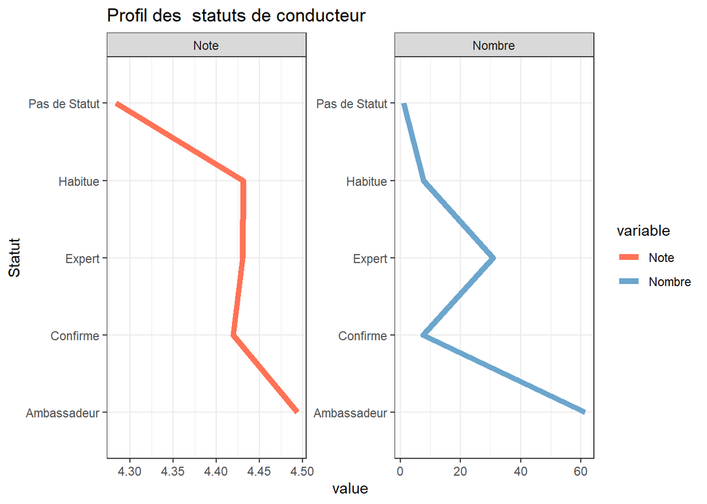

```r
foo<-df %>%
  group_by(Statut)%>%
  summarise(Note=mean(Note,na.rm=TRUE),Nombre=mean(Nombre,na.rm=TRUE))

foo<-melt(foo)

ggplot(foo, aes(x=Statut, y=value,group=variable))+
  geom_line(aes(color=variable), size=2)+
  theme_bw() +
  coord_flip()+
  facet_wrap(vars(variable),scales ="free")+
  labs(title = "Profil des  statuts de conducteur")+scale_color_manual(values=c("coral1", "skyblue3"))
```

les notes sont en moyenne de 4.45 et fortement déviées à droite, réduisant la capacité de discrimination.

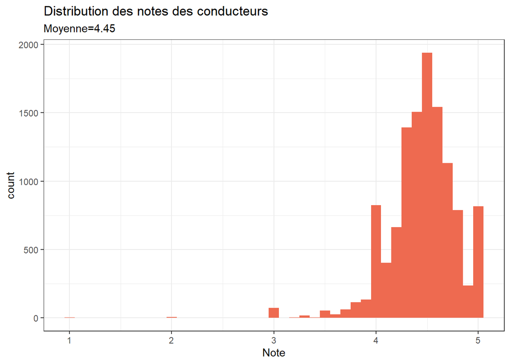

```r
mean<-round(mean(df$Note,na.rm=TRUE),2)
ggplot(df, aes(x=Note))+geom_histogram(fill="coral2",binwidth = .1)+
  theme_bw() +
  labs(title = "Distribution des notes des conducteurs", subtitle =paste0("Moyenne=", mean))
```

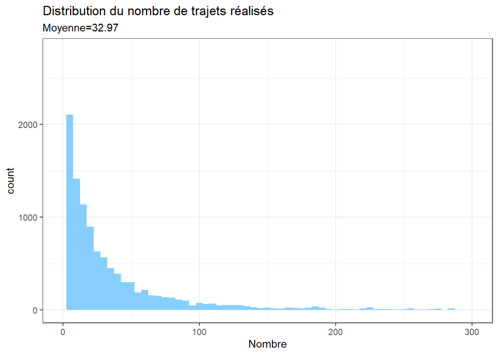

```r
mean<-round(mean(df$Nombre,na.rm=TRUE),2)

ggplot(df, aes(x=Nombre))+geom_histogram(fill="skyblue1", binwidth = 5)+theme_bw()+labs(title = "Distribution du nombre de trajets réalisés", subtitle =paste0("Moyenne=", mean))+xlim(0,300)
```

Note et expérience sont-ils corrélés? Rien de très probant même s’il semble que la note s’accroisse légèrement avec le nombre de voyages réalisés.

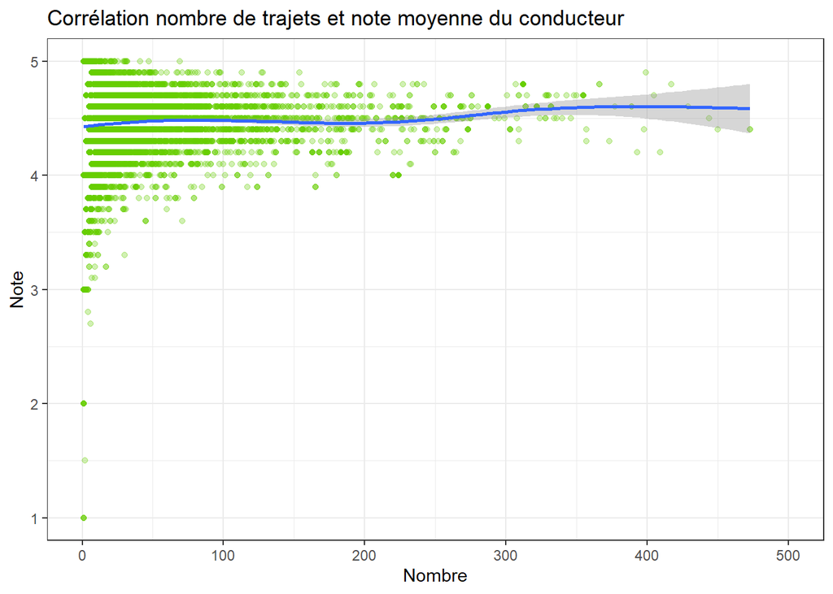

```r
ggplot(df, aes(x=Nombre, y=Note))+
  geom_point(color="Chartreuse3",alpha=0.3)+
  theme_bw() +geom_smooth()+
  xlim(0,500)+labs(title="Corrélation nombre de trajets et note moyenne du conducteur")
```

## Analyser la demande

On utilise la variable nombre de place restante qu’on traduit par un indicateur codé de 0 (tout est libre) à 1 ( la voiture est pleine). En voici la distribution.

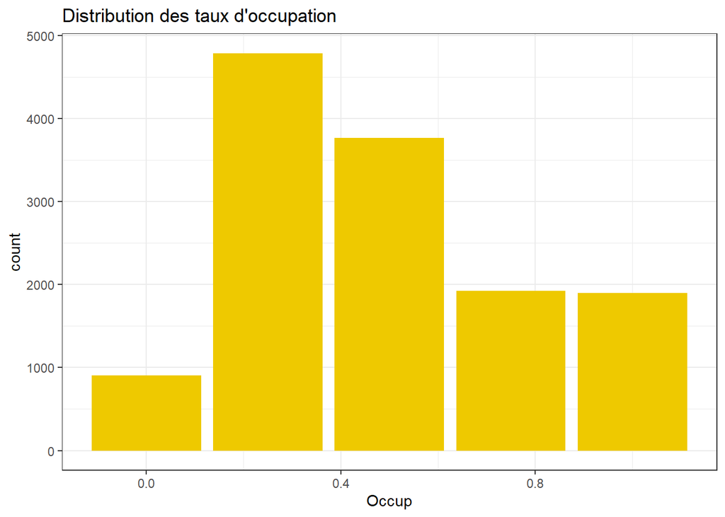

```r
ggplot(df, aes(x=Occup))+geom_bar(fill="gold2")+theme_bw()  +labs(title="Distribution des taux d'occupation")
```

### Un modèle OLS

On commence par un modèle simple et linéaire où l’on cherche à expliquer, prédire, le taux d’occupation du véhicule en fonction des variables dont nous disposons. La flexibilité de l’horaire et la possibilité de détour n’affecte pas vraiment le taux de réservation. Si les autres variables ont des relations significatives ( avec des valeur t très élevées), on notera que la variance expliquée est faible.

Le remplissage des voiture est une affaire de loto. Ce qui se comprend, car la probabilité qu’une offre et une demande coincide est relativement faible si on retient une plage horaire étroite pour le passager qui l’élargira pour accroître son choix au prix d’un effort supplémentaire de recherche.

```r
fit0<-lm(Occup~Age+Distance+Prix+Flex+Detour+Autoroute+Statut+log(Nombre+1)+Note, data=df)
summ(fit0)
```

| Observations | 11706 (1579 missing obs. deleted) |
| --- | --- |
| Dependent variable | Occup |
| Type | OLS linear regression |

| F(14,11691) | 19.88 |
| --- | --- |
| R² | 0.02 |
| Adj. R² | 0.02 |

|  | Est. | S.E. | t val. | p |
| --- | --- | --- | --- | --- |
| (Intercept) | 0.20 | 0.04 | 4.60 | 0.00 |
| Age | -0.00 | 0.00 | -4.26 | 0.00 |
| Distance | 0.00 | 0.00 | 8.96 | 0.00 |
| Prix | -0.01 | 0.00 | -8.39 | 0.00 |
| FlexPas d’indication | 0.01 | 0.01 | 1.81 | 0.07 |
| FlexVoir avec le conducteur | 0.01 | 0.03 | 0.32 | 0.75 |
| DetourDe 15 minutes max | -0.00 | 0.01 | -0.47 | 0.64 |
| DetourPlus de 15 mn | -0.07 | 0.03 | -2.39 | 0.02 |
| AutorouteOui | 0.11 | 0.02 | 6.97 | 0.00 |
| StatutConfirme | -0.03 | 0.01 | -2.81 | 0.00 |
| StatutExpert | -0.02 | 0.01 | -2.72 | 0.01 |
| StatutHabitue | -0.05 | 0.01 | -4.47 | 0.00 |
| StatutPas de Statut | -0.07 | 0.02 | -3.61 | 0.00 |
| log(Nombre + 1) | -0.02 | 0.00 | -6.59 | 0.00 |
| Note | 0.06 | 0.01 | 7.32 | 0.00 |

Standard errors: OLS

Les deux modèles sont représentés dans un diagramme de paramètres qui permet de mieux illustrer les résultats qu’un tableau classique de paramètres de régression. On emploie `jtools` pour les représentations graphiques.

```r
fit1<-lm(Occup~Age+Distance+Prix+Flex+Detour+Autoroute+Statut+log(Nombre+1)+Note:log(Nombre+1), data=df)
summ(fit1)
```

| Observations | 11706 (1579 missing obs. deleted) |
| --- | --- |
| Dependent variable | Occup |
| Type | OLS linear regression |

| F(14,11691) | 21.43 |
| --- | --- |
| R² | 0.03 |
| Adj. R² | 0.02 |

|  | Est. | S.E. | t val. | p |
| --- | --- | --- | --- | --- |
| (Intercept) | 0.46 | 0.02 | 20.69 | 0.00 |
| Age | -0.00 | 0.00 | -4.11 | 0.00 |
| Distance | 0.00 | 0.00 | 8.94 | 0.00 |
| Prix | -0.01 | 0.00 | -8.42 | 0.00 |
| FlexPas d’indication | 0.01 | 0.01 | 1.80 | 0.07 |
| FlexVoir avec le conducteur | 0.01 | 0.03 | 0.35 | 0.73 |
| DetourDe 15 minutes max | -0.00 | 0.01 | -0.38 | 0.70 |
| DetourPlus de 15 mn | -0.06 | 0.03 | -2.37 | 0.02 |
| AutorouteOui | 0.11 | 0.02 | 7.09 | 0.00 |
| StatutConfirme | -0.03 | 0.01 | -2.55 | 0.01 |
| StatutExpert | -0.02 | 0.01 | -2.28 | 0.02 |
| StatutHabitue | -0.05 | 0.01 | -4.21 | 0.00 |
| StatutPas de Statut | -0.07 | 0.02 | -3.71 | 0.00 |
| log(Nombre + 1) | -0.16 | 0.02 | -9.82 | 0.00 |
| log(Nombre + 1):Note | 0.03 | 0.00 | 8.65 | 0.00 |

Standard errors: OLS

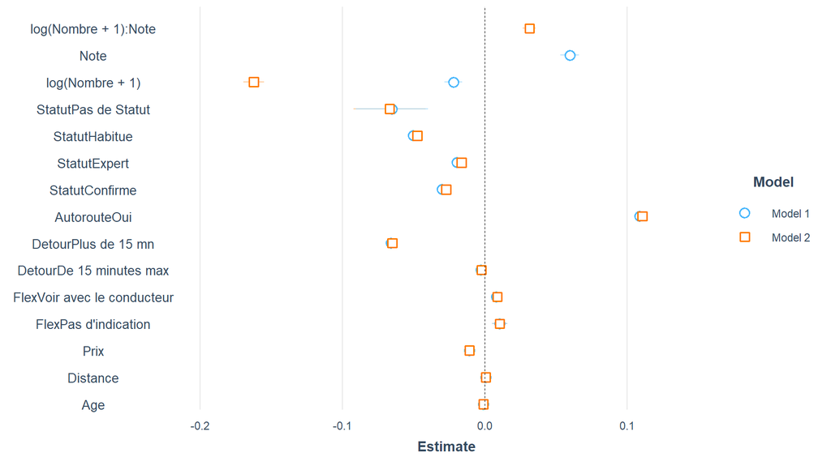

```r
plot_summs(fit0,fit1, plot.distributions = TRUE,scale = FALSE)
```

Le modèle tient même s’il explique très peu de variance. Les tests sont cependant significatifs et même si l’effet est faible il est notable. Voici des diagrammes d’effets qui représentent la valeur de la variable dépendante pour une plage de variation des variables indépendantes prises une à une, en fonction du modèle. On voit ainsi plus clairement que le taux d’occupation passe de 20% environ quand la note est de 3 (les notes inférieures sont rares!) à 45% quand la moyenne du conducteur frôle les 5.

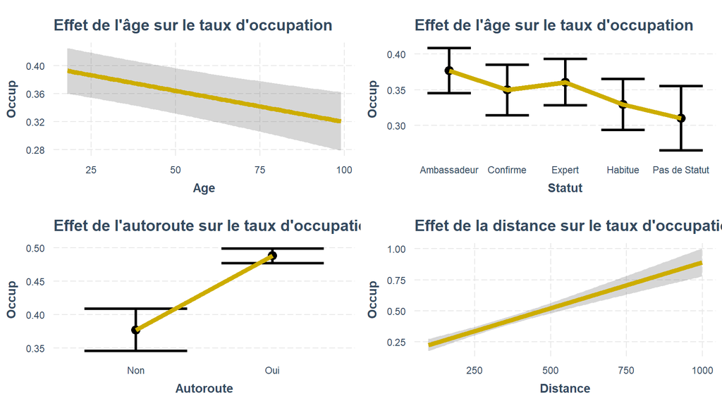

```r
g10<-effect_plot(fit1, pred=Age,interval = TRUE ,data=df)+geom_line(color="gold3",size=2)+labs(title="Effet de l'âge sur le taux d'occupation")
g11<-effect_plot(fit1, pred=Statut,interval = TRUE ,data=df)+geom_line(color="gold3",size=2)+labs(title="Effet de l'âge sur le taux d'occupation")
g12<-effect_plot(fit1, pred=Autoroute,interval = TRUE  ,data=df)+geom_line(color="gold3",size=2)+labs(title="Effet de l'autoroute sur le taux d'occupation")
g13<-effect_plot(fit1, pred=Distance,interval = TRUE  ,data=df)+geom_line(color="gold3",size=2)+labs(title="Effet de la distance sur le taux d'occupation")
grid.arrange(g10,g11,g12,g13,ncol=2)
```

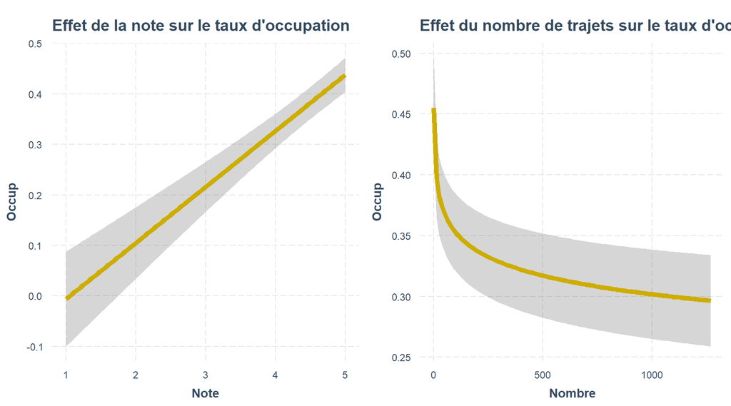

```r
g14<-effect_plot(fit1, pred=Note,interval = TRUE ,data=df)+geom_line(color="gold3",size=2)+labs(title="Effet de la note sur le taux d'occupation")
g15<-effect_plot(fit1, pred=Nombre,interval = TRUE  ,data=df)+geom_line(color="gold3",size=2)+labs(title="Effet du nombre de trajets sur le taux d'occupation")
grid.arrange(g14,g15,ncol=2)
```

La particularité du modèle est le terme d’interaction. L’expérience du conducteur traduite par le nombre de trajets qu’il a effectué est gage de sécurité, de confiance, pourvu que ses notes soient bonnes. On s’attend à ce que si elle sont moins bonnes, le nombre de voyages réalisés en amplifiera l’impact négatif. L’expérience signale aussi la crédibilité de la note, et on peut raisonnablement penser que plus ce nombre est grand et plus le signal, positif ou négatif est crédible. Ici la note module l’effet de crédibilité.

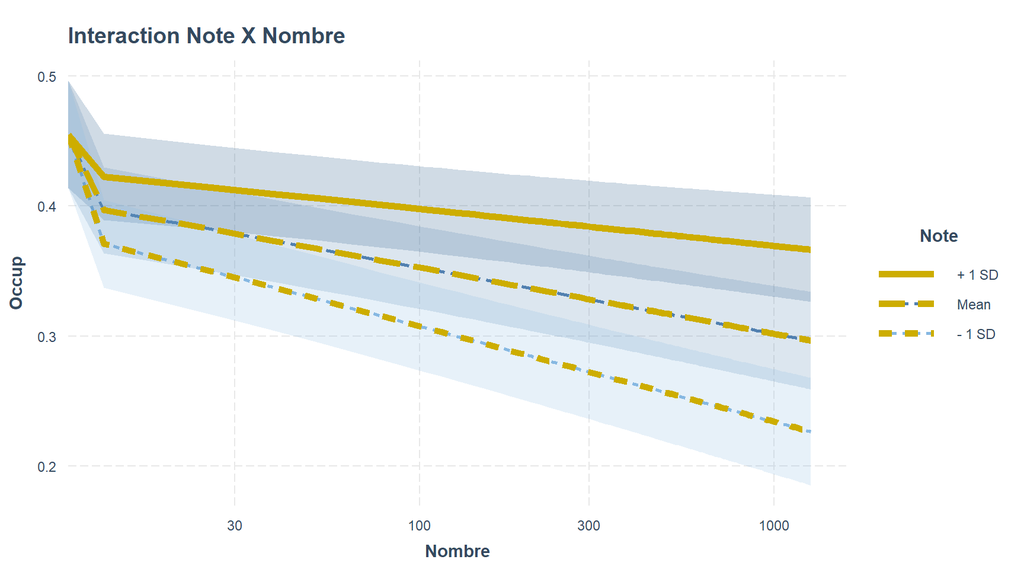

```r
library(interactions)
interact_plot(fit1,pred =Nombre , modx =Note ,interval = TRUE ,data=df) +scale_x_log10()+geom_line(color="gold3",size=2)+labs(title="Interaction Note X Nombre")
```

### Un modèle plus raffiné

On apporte deux ajustements :

l’estimation est réalisée avec `lme4`

Les effets semblent être ici plus pertinent et sensibles mais surtout l’effet d’interaction semble renforcé. L’effet de la note est là clairement amplifié pour les notes négatives mais aussi pour les notes positives.

```r
fit2<-glmer(Occup~Age+Statut+Distance+Prix+Autoroute+log(Nombre+1)+Note:log(Nombre+1)+(1|trajet),family = binomial, data=df)
summ(fit2)
```

| Observations | 11706 |
| --- | --- |
| Dependent variable | Occup |
| Type | Mixed effects generalized linear model |
| Family | binomial |
| Link | logit |

| AIC | 13913.06 |
| --- | --- |
| BIC | 14001.47 |
| Pseudo-R² (fixed effects) | 0.02 |
| Pseudo-R² (total) | 0.02 |

| Fixed Effects | Fixed Effects Est. | Fixed Effects S.E. | Fixed Effects z val. | Fixed Effects p |
| --- | --- | --- | --- | --- |
| (Intercept) | -1.10 | 0.18 | -6.20 | 0.00 |
| Age | -0.01 | 0.00 | -3.00 | 0.00 |
| StatutConfirme | -0.18 | 0.08 | -2.19 | 0.03 |
| StatutExpert | -0.17 | 0.06 | -3.09 | 0.00 |
| StatutHabitue | -0.39 | 0.09 | -4.42 | 0.00 |
| StatutPas de Statut | -0.16 | 0.14 | -1.14 | 0.25 |
| Distance | 0.01 | 0.00 | 8.17 | 0.00 |
| Prix | -0.08 | 0.01 | -7.89 | 0.00 |
| AutorouteOui | 0.62 | 0.13 | 4.65 | 0.00 |
| log(Nombre + 1) | -0.77 | 0.13 | -5.85 | 0.00 |
| log(Nombre + 1):Note | 0.15 | 0.03 | 5.39 | 0.00 |

| Random Effects Group | Random Effects Parameter | Random Effects Std. Dev. |
| --- | --- | --- |
| trajet | (Intercept) | 0.00 |

| Grouping Variables Group | Grouping Variables # groups | Grouping Variables ICC |
| --- | --- | --- |
| trajet | 36 | 0.00 |

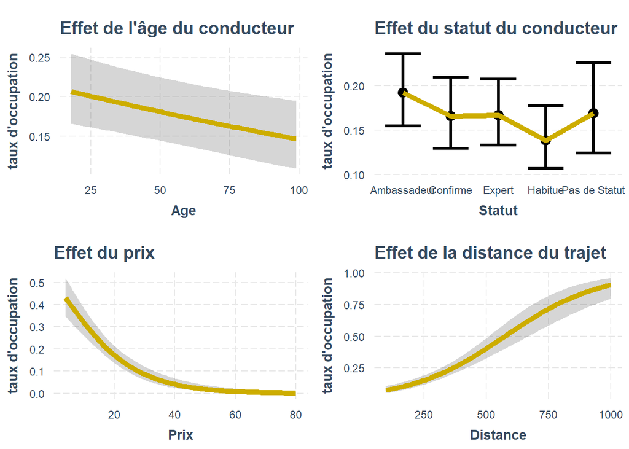

```r
g16a<-effect_plot(fit2, pred=Age,interval = TRUE  ,data=df)+geom_line(color="gold3",size=2)+labs(title="Effet de l'âge du conducteur",y="taux d'occupation" )
g16b<-effect_plot(fit2, pred=Statut,interval = TRUE  ,data=df)+geom_line(color="gold3",size=2)+labs(title="Effet du statut du conducteur",y="taux d'occupation")
g16<-effect_plot(fit2, pred=Prix,interval = TRUE  ,data=df)+geom_line(color="gold3",size=2)+labs(title="Effet du prix",y="taux d'occupation")
g17<-effect_plot(fit2, pred=Distance,interval = TRUE  ,data=df)+geom_line(color="gold3",size=2)+labs(title="Effet de la distance du trajet",y="taux d'occupation")
grid.arrange(g16a,g16b,g16,g17,ncol=2)
```

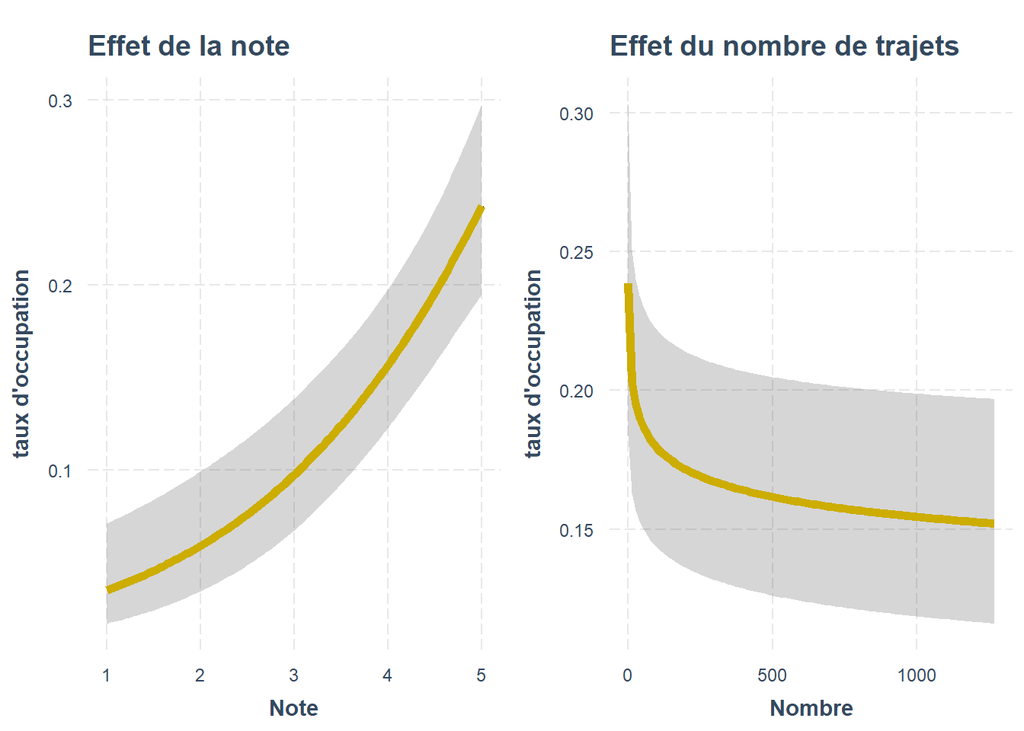

```r
g18<-effect_plot(fit2, pred=Note,interval = TRUE  ,data=df)+geom_line(color="gold3",size=2)+labs(title="Effet de la note",y="taux d'occupation")
g19<-effect_plot(fit2, pred=Nombre,interval = TRUE ,data=df)+geom_line(color="gold3", size=2)+labs(title="Effet du nombre de trajets",y="taux d'occupation")
grid.arrange(g18,g19,ncol=2)
```

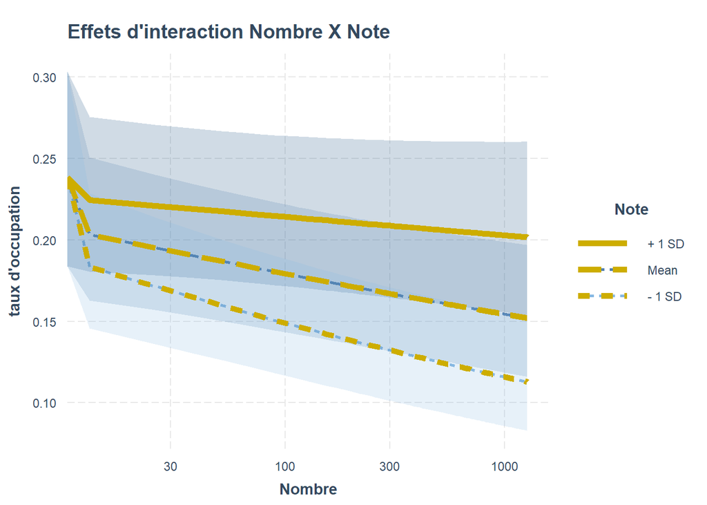

```r
g20<-interact_plot(fit2,pred =Nombre , modx =Note ,interval = TRUE ,data=df) +scale_x_log10()+geom_line(color="gold3", size=2)+labs(title="Effets d'interaction Nombre X Note",y="taux d'occupation")
g20
```

## L’offre et donc le prix

Le prix est un facteur important, du moins parmi ceux donc le conducteur dispose pour remplir son véhicule et optimiser son revenu.

On s’attend de manière générale à ce que si le conducteur est correctement signalé : il a de bonne note et une grande expérience, à ce qu’il tire avantage de cette qualification en accroissant le prix qu’il offre par rapport à d’autre conducteurs moins aguéris au système et moins bien évalués.

L’hypothèse symétrique doit aussi être considérée : celle qui considère que les conducteurs expérimentés offrent des prix plus faibles pour bénéficier d’un avantage de réputation. Si les notes ont un effet positif sur le remplissage du véhicule, il est peut-être avantageux de baisser les prix.

Examinons les faits.

## Analyse des prix

Au premier examen la distribution des prix semble être multimodale, en fait elle est étroitement associée à la distribution des distance. Le prix est une multiplication de la distance par un tarif kilométrique, même si la relation ne semble pas tout à faire linéaire.

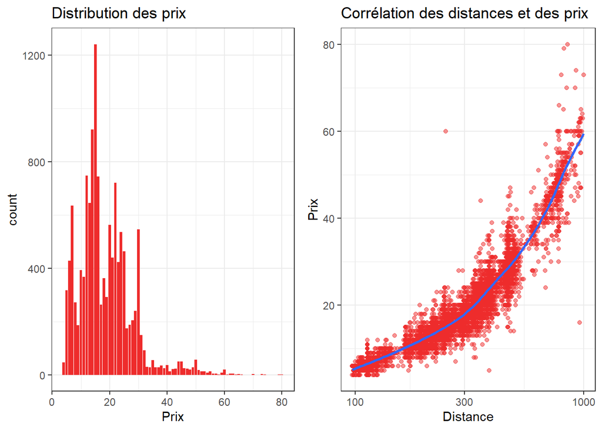

```r
g20<-ggplot(df, aes(x=Prix))+geom_bar(fill="firebrick2")+theme_bw()  +labs(title = "Distribution des prix")
g21<-ggplot(df, aes(x=Distance, y=Prix))+geom_point(color="firebrick2", alpha =0.5)+theme_bw() +geom_smooth(method="gam")+scale_x_log10()+labs(title = "Corrélation des distances et des prix")
library(gridExtra)
grid.arrange(g20,g21, ncol=2)
```

C’est pourquoi on calcule un tarif au km, qui lui n’est plus corrélé ou presque à la distance parcourue.

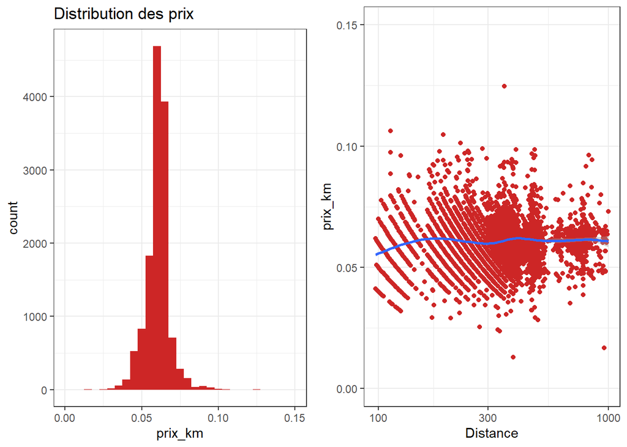

```r
df$prix_km<-df$Prix/df$Distance

g22<-ggplot(df, aes(x=prix_km))+geom_histogram(fill="firebrick3", binwidth = 0.005)+theme_bw()  +labs(title = "Distribution des prix")+xlim(0,0.15)
g23<-ggplot(df, aes(x=Distance, y=prix_km))+geom_point(color="firebrick3")+theme_bw() +geom_smooth(method="gam")+scale_x_log10()+ylim(0,0.15)
grid.arrange(g22,g23, ncol=2)
```

## Analyse du prix

```r
fit3<-lm(prix_km~Age+Distance+Autoroute+log(Nombre+1)+Note, data=df)
summ(fit3)
```

| Observations | 11706 (1579 missing obs. deleted) |
| --- | --- |
| Dependent variable | prix_km |
| Type | OLS linear regression |

| F(5,11700) | 179.58 |
| --- | --- |
| R² | 0.07 |
| Adj. R² | 0.07 |

|  | Est. | S.E. | t val. | p |
| --- | --- | --- | --- | --- |
| (Intercept) | 0.06 | 0.00 | 56.91 | 0.00 |
| Age | 0.00 | 0.00 | 9.18 | 0.00 |
| Distance | 0.00 | 0.00 | 11.30 | 0.00 |
| AutorouteOui | 0.01 | 0.00 | 22.27 | 0.00 |
| log(Nombre + 1) | -0.00 | 0.00 | -9.61 | 0.00 |
| Note | -0.00 | 0.00 | -5.15 | 0.00 |

Standard errors: OLS

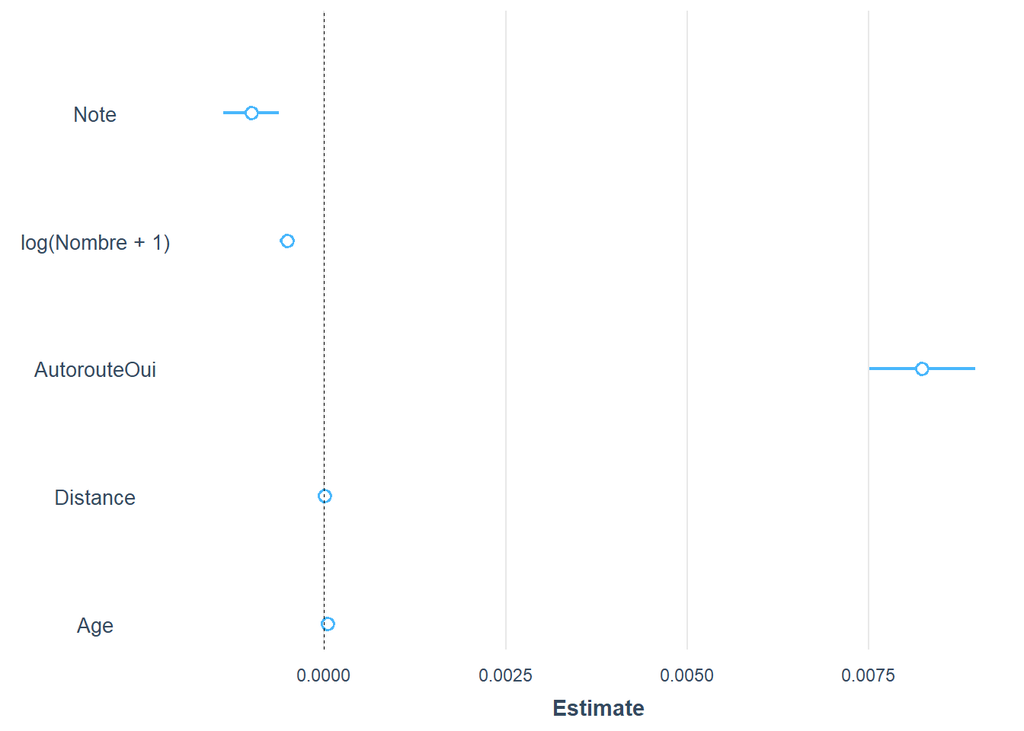

```r
plot_summs(fit3,  plot.distributions = TRUE,scale = FALSE)
```

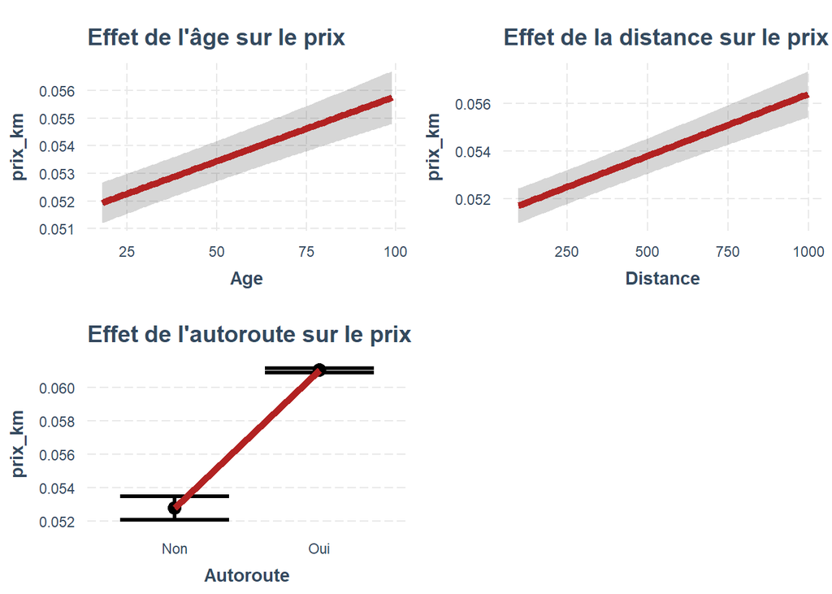

```r
g24<-effect_plot(fit3, pred=Age,interval = TRUE ,data=df)+geom_line(color="firebrick",size=2)+labs(title="Effet de l'âge sur le prix")
g25<-effect_plot(fit3, pred=Distance,interval = TRUE ,data=df)+geom_line(color="firebrick",size=2)+labs(title="Effet de la distance sur le prix")
g27<-effect_plot(fit3, pred=Autoroute,interval = TRUE ,data=df)+geom_line(color="firebrick",size=2)+labs(title="Effet de l'autoroute sur le prix")

g26<-effect_plot(fit3, pred=Note,interval = TRUE ,data=df)+geom_line(color="firebrick",size=2)+labs(title="Effet de la note sur le prix")
g28<-effect_plot(fit3, pred=Nombre,interval = TRUE ,data=df)+geom_line(color="firebrick",size=2)+labs(title="Effet du nombre de trajets")
g29<-interact_plot(fit3,pred =Nombre , modx =Note ,interval = TRUE ,data=df) +scale_x_log10()+geom_line(color="firebrick",size=2)+labs(title="Interaction nombre X Note")

grid.arrange(g24,g25,g27, ncol=2)
```

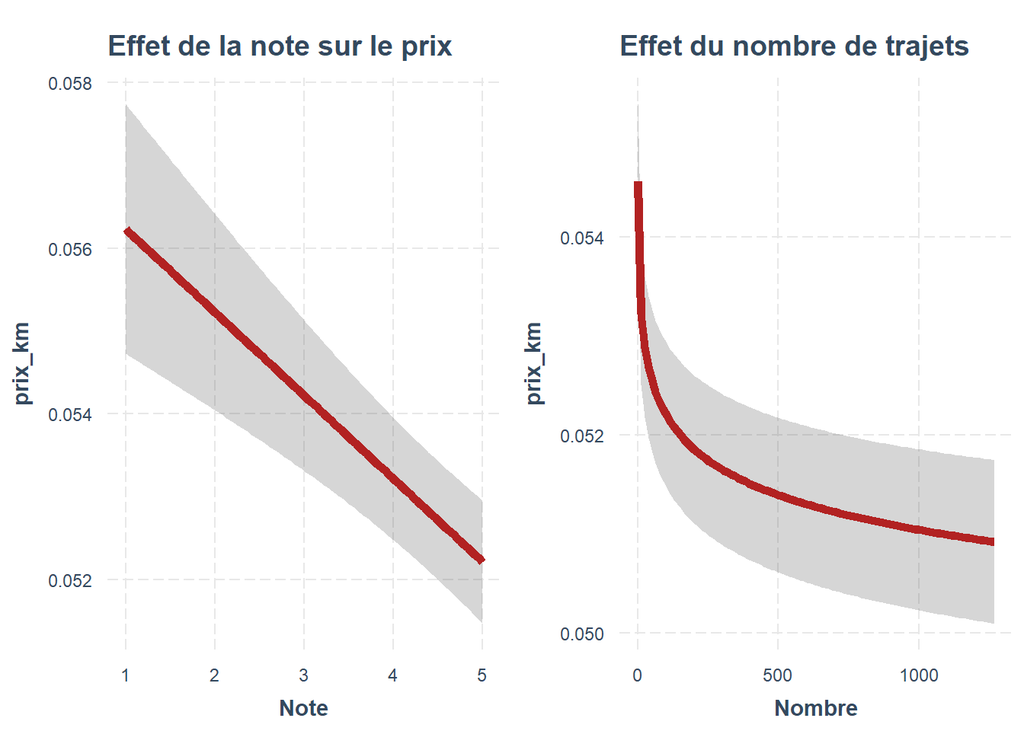

```r
grid.arrange(g26,g28, ncol=2)
```

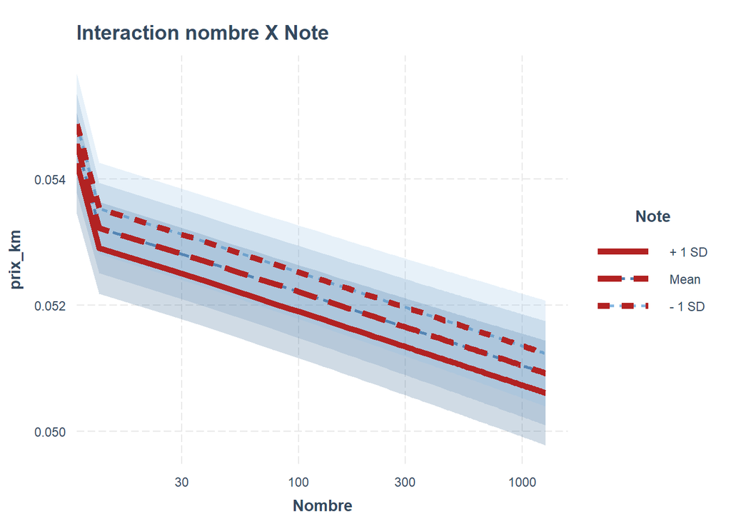

```r
g29
```

On ajoute l’effet des départs et des arrivées en composantes d’erreur pour capturer l’hétérogénéité.

Ici par d’interaction :

```r
fit4<-lmer(prix_km~Distance+Autoroute+Age+Note+log(Nombre+1):Note+(1|trajet), data=df)
summary(fit4)
```

```
## Linear mixed model fit by REML ['lmerMod']
## Formula: prix_km ~ Distance + Autoroute + Age + Note + log(Nombre + 1):Note +
##     (1 | trajet)
##    Data: df
##
## REML criterion at convergence: -83637.9
##
## Scaled residuals:
##     Min      1Q  Median      3Q     Max
## -6.1783 -0.4504  0.0499  0.4561  9.1001
##
## Random effects:
##  Groups   Name        Variance  Std.Dev.
##  trajet   (Intercept) 3.046e-06 0.001745
##  Residual             4.542e-05 0.006739
## Number of obs: 11706, groups:  trajet, 36
##
## Fixed effects:
##                        Estimate Std. Error t value
## (Intercept)           5.787e-02  1.133e-03  51.093
## Distance             -2.858e-06  1.471e-06  -1.943
## AutorouteOui          8.157e-03  3.978e-04  20.505
## Age                   4.381e-05  4.996e-06   8.769
## Note                 -6.793e-04  1.926e-04  -3.527
## Note:log(Nombre + 1) -1.370e-04  1.157e-05 -11.839
##
## Correlation of Fixed Effects:
##             (Intr) Distnc AutrtO Age    Note
## Distance    -0.463
## AutorouteOu -0.319 -0.042
## Age         -0.201 -0.019 -0.006
## Note        -0.746  0.000 -0.002  0.085
## Nt:lg(Nm+1) -0.013  0.054  0.035 -0.072 -0.185
```

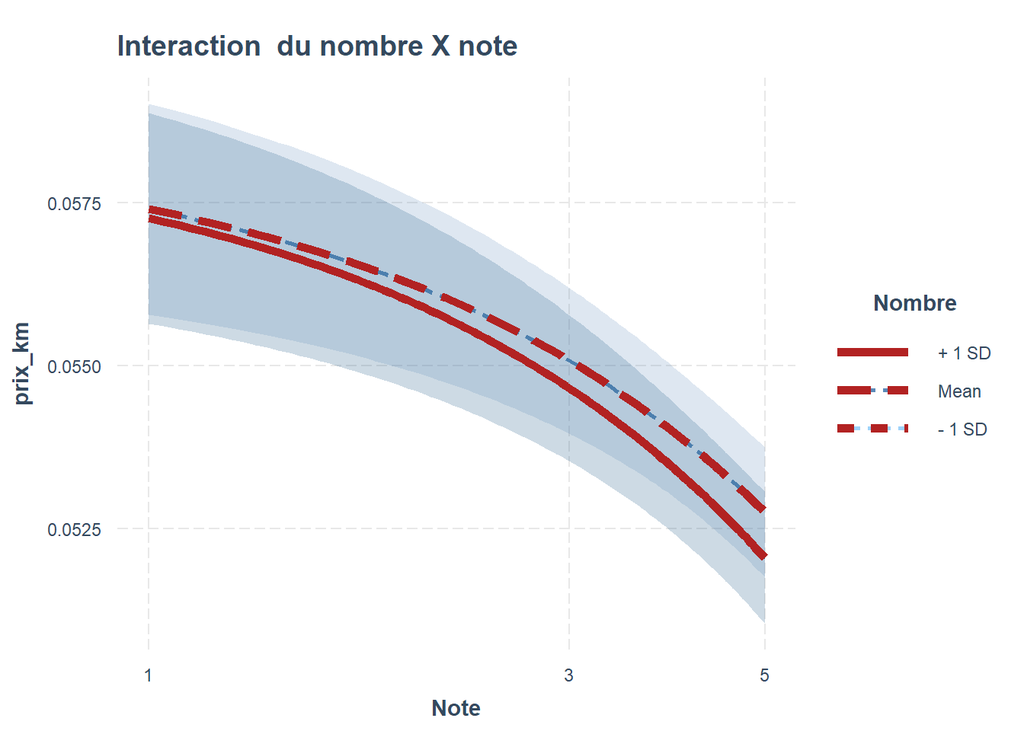

```r
interact_plot(fit4,pred =Note , modx =Nombre ,interval = TRUE ,data=df) +scale_x_log10()+geom_line(color="firebrick",size=2)+
  labs(title="Interaction  du nombre X note")
```

## Conclusions

les résultats obtenus montrent d’abord que les échanges dans les plateformes C2C répondent à une logique de marché dans laquelle les stratégies de signaling jouent un rôle certain même s’il est en fait assez marginal au regard des résultats empiriques. Elles expliquent une faible variance des critères retenus : le taux d’occupation du véhicule au moment de la recherche, et le prix proposé par les conducteurs.

Du côté de la demande on on observera que ce sont les caractérisques d’offre qui dominent. Le prix est déterminant autant que la réputation,

Du côté de l’offre on observe cependant une chose étonnante : l’expérience et la qualité de l’évaluation ne se traduisent pas par des comportements de valorisation de la qualité mais au contraire par des stratégies de prix plus bas.

L’enigme est de savoir pourquoi : s’agit-il simplement d’une stratégie de sécurisation , ceux qui ont l’expérience ont appris qu’en fixant un prix un peu plus bas on s’assure de remplir le véhicule, ou d’une manière de signaler qu’on est un pro du collaboratif et de la générosité et que le prix plus bas signale cette qualité ?

D’autres analyse sont nécessaires sans doute avec une approche plus segmentée à l’instar des deux derniers graphes qui représentent les modèles estimés précédemment mais pour chaque groupe de statut.

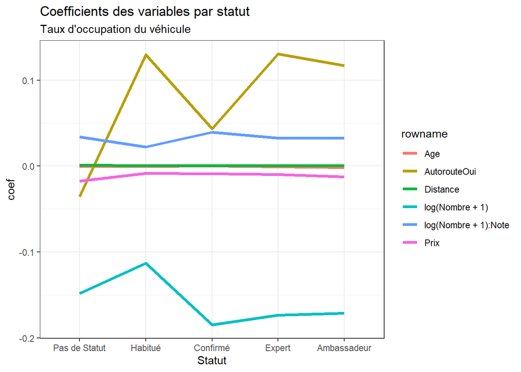

```r
models <- df %>% group_by(Statut) %>% summarise(mod = list(lm(Occup~Age+Distance+Autoroute+Prix+log(Nombre+1)+Note:log(Nombre+1))))
coef5<-as.data.frame(models$mod[[1]]$coefficients)%>%add_rownames()%>%mutate(Statut="Ambassadeur")%>% rename(coef=2)
coef1<-as.data.frame(models$mod[[2]]$coefficients)%>%add_rownames()%>% mutate(Statut="Confirmé")%>% rename(coef=2)
coef2<-as.data.frame(models$mod[[3]]$coefficients)%>%add_rownames()%>%mutate(Statut="Expert")%>% rename(coef=2)
coef3<-as.data.frame(models$mod[[4]]$coefficients)%>%add_rownames()%>%mutate(Statut="Habitué")%>% rename(coef=2)
coef4<-as.data.frame(models$mod[[5]]$coefficients)%>%add_rownames()%>%mutate(Statut="Pas de Statut")%>% rename(coef=2)

coef<-rbind(coef1, coef2, coef3, coef4, coef5) %>% filter(rowname!="(Intercept)")
coef$Statut <- factor(coef$Statut, levels = c("Pas de Statut", "Habitué", "Confirmé", "Expert", "Ambassadeur"))


ggplot(coef, aes(x=Statut,y=coef,group=rowname))+geom_line(aes(color=rowname), size=1.3)+theme_bw()+labs(title="Coefficients des variables par statut",subtitle = "Taux d'occupation du véhicule")
```

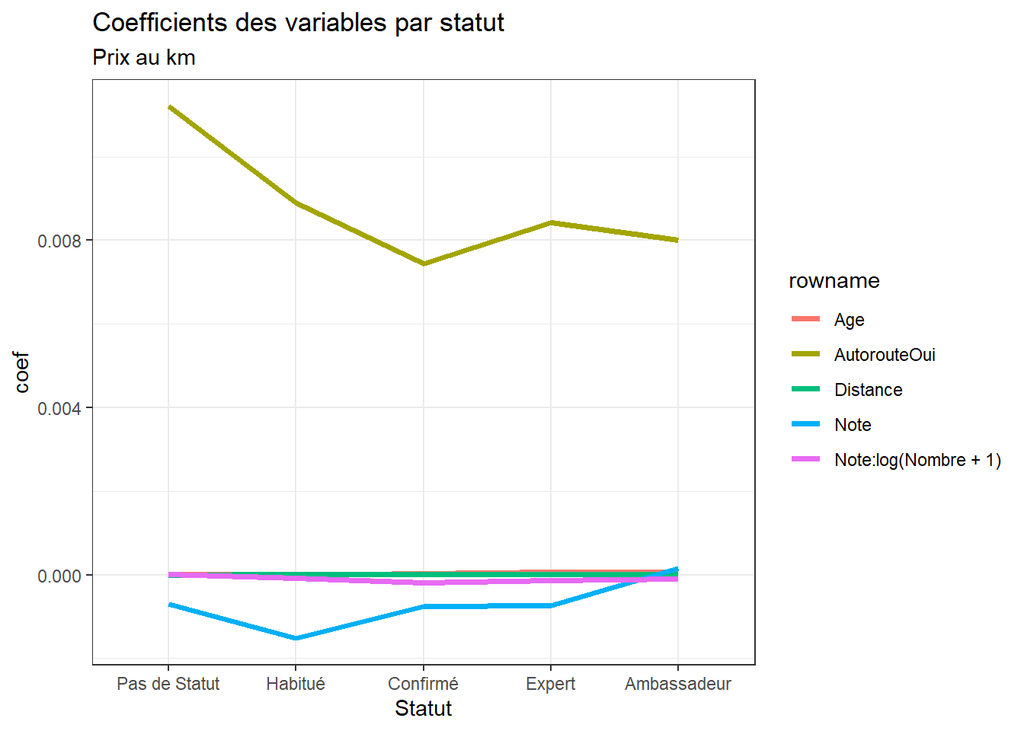

```r
models <- df %>% group_by(Statut) %>% summarise(mod = list(lm(prix_km~Distance+Autoroute+Age+Note+log(Nombre+1):Note)))
coef5<-as.data.frame(models$mod[[1]]$coefficients)%>%add_rownames()%>%mutate(Statut="Ambassadeur")%>% rename(coef=2)
coef1<-as.data.frame(models$mod[[2]]$coefficients)%>%add_rownames()%>% mutate(Statut="Confirmé")%>% rename(coef=2)
coef2<-as.data.frame(models$mod[[3]]$coefficients)%>%add_rownames()%>%mutate(Statut="Expert")%>% rename(coef=2)
coef3<-as.data.frame(models$mod[[4]]$coefficients)%>%add_rownames()%>%mutate(Statut="Habitué")%>% rename(coef=2)
coef4<-as.data.frame(models$mod[[5]]$coefficients)%>%add_rownames()%>%mutate(Statut="Pas de Statut")%>% rename(coef=2)

coef<-rbind(coef1, coef2, coef3, coef4, coef5) %>% filter(rowname!="(Intercept)")
coef$Statut <- factor(coef$Statut, levels = c("Pas de Statut", "Habitué", "Confirmé", "Expert", "Ambassadeur"))


ggplot(coef, aes(x=Statut,y=coef,group=rowname))+geom_line(aes(color=rowname), size=1.3)+theme_bw()+labs(title="Coefficients des variables par statut",subtitle = "Prix au km")
```